# chapter5

Loading the required libraries

```r
library(dplyr)
library(tidyr)
library(ggplot2)
library(GGally)
library(boot)
library(MASS)
library(corrplot)
library(tidyverse)
library(plotly)
library(stringr)
library(FactoMineR)
```

### Data wrangling

Loading human.csv data and carrying out the required data wrangling.

```r
human <- read.table("data/human.csv", sep=",", header=TRUE, check.names=FALSE, row.names = 1)
str(human)
```

```
## 'data.frame':    195 obs. of  19 variables:
##  $ hdirank     : int  1 2 3 4 5 6 6 8 9 9 ...
##  $ country     : Factor w/ 195 levels "Afghanistan",..: 129 10 169 48 124 67 84 186 34 125 ...
##  $ hdi         : num  0.944 0.935 0.93 0.923 0.922 0.916 0.916 0.915 0.913 0.913 ...
##  $ lifeexp     : num  81.6 82.4 83 80.2 81.6 80.9 80.9 79.1 82 81.8 ...
##  $ eduexp      : num  17.5 20.2 15.8 18.7 17.9 16.5 18.6 16.5 15.9 19.2 ...
##  $ meanedu     : num  12.6 13 12.8 12.7 11.9 13.1 12.2 12.9 13 12.5 ...
##  $ gni         : Factor w/ 194 levels "1,096","1,123",..: 166 135 156 139 140 137 127 154 134 117 ...
##  $ gniminusrank: int  5 17 6 11 9 11 16 3 11 23 ...
##  $ giirank     : int  1 2 3 4 5 6 6 8 9 9 ...
##  $ gii         : num  0.067 0.11 0.028 0.048 0.062 0.041 0.113 0.28 0.129 0.157 ...
##  $ matmor      : int  4 6 6 5 6 7 9 28 11 8 ...
##  $ adobir      : num  7.8 12.1 1.9 5.1 6.2 3.8 8.2 31 14.5 25.3 ...
##  $ fparli      : num  39.6 30.5 28.5 38 36.9 36.9 19.9 19.4 28.2 31.4 ...
##  $ secedf      : num  97.4 94.3 95 95.5 87.7 96.3 80.5 95.1 100 95 ...
##  $ secedm      : num  96.7 94.6 96.6 96.6 90.5 97 78.6 94.8 100 95.3 ...
##  $ labf        : num  61.2 58.8 61.8 58.7 58.5 53.6 53.1 56.3 61.6 62 ...
##  $ labm        : num  68.7 71.8 74.9 66.4 70.6 66.4 68.1 68.9 71 73.8 ...
##  $ secedfm     : num  1.007 0.997 0.983 0.989 0.969 ...
##  $ labfm       : num  0.891 0.819 0.825 0.884 0.829 ...
```

```r
dim(human)
```

```
## [1] 195  19
```

The variables have been derived from two datasets. First is the data used to create Human Devlopment Index (HDI). HDI was developed by the UNDP. The Gender Inequality Index is also devloped by the UNDP. According to the UNDP website, It measures gender inequalities in three important aspects of human development—reproductive health, measured by maternal mortality ratio and adolescent birth rates; empowerment, measured by proportion of parliamentary seats occupied by females; and economic status, expressed as labour market participation. The variables we will be using from these dataset are:

**country**: The country being described **hdirank**: HDI rank, which tells what is the rank of the country in terms of Human development index **hdi**: The Human Devleopment Index score **lifeexp**: Life expectancy at birth **eduexp**: Expected years of schooling **meanedu**: Mean years of schooling **gni**: gross national income per capita **gniminusrank**: Gross national income per capita rank minus HDI rank **giirank**: Gender Inequality Index rank **gii**: The Gender Inequality Index score **matmor**: Maternal mortality ratio **adobir**: Adolescent birth rate **fparli**: Percent representation of women in parliament **secedf**: Percent population (women) with secondary education **secedm**: Percent population (men) with secondary education **labf**: Percent participation (of women) in labor force **labm**: Percent participation (of men) in labor force

Using the above variables, following additional variables were created

**secedfm**: Ratio between % women and % men with secondary education **labfm**: Ratio between % women and % men in labor force

Now let’s make the changes as instructed in the exercise 5, data wrangling part

```r
func <- str_replace(human$gni, pattern=",", replace ="")  %>% as.numeric

human <- mutate(human, gni = func)

selcols <- c("country","secedfm","labfm","eduexp","lifeexp","gni","matmor","adobir","fparli")
human <- dplyr::select(human, one_of(selcols))

comp <- complete.cases(human)
data.frame(human[-1], comp = comp)
```

```
##       secedfm     labfm eduexp lifeexp    gni matmor adobir fparli  comp
## 1   1.0072389 0.8908297   17.5    81.6  64992      4    7.8   39.6  TRUE
## 2   0.9968288 0.8189415   20.2    82.4  42261      6   12.1   30.5  TRUE
## 3   0.9834369 0.8251001   15.8    83.0  56431      6    1.9   28.5  TRUE
## 4   0.9886128 0.8840361   18.7    80.2  44025      5    5.1   38.0  TRUE
## 5   0.9690608 0.8286119   17.9    81.6  45435      6    6.2   36.9  TRUE
## 6   0.9927835 0.8072289   16.5    80.9  43919      7    3.8   36.9  TRUE
## 7   1.0241730 0.7797357   18.6    80.9  39568      9    8.2   19.9  TRUE
## 8   1.0031646 0.8171263   16.5    79.1  52947     28   31.0   19.4  TRUE
## 9   1.0000000 0.8676056   15.9    82.0  42155     11   14.5   28.2  TRUE
## 10  0.9968520 0.8401084   19.2    81.8  32689      8   25.3   31.4  TRUE
## 11  0.9148148 0.7616580   15.4    83.0  76628      6    6.0   25.3  TRUE
## 12  0.9116162 0.7566372   15.6    84.0  53959     NA    3.3     NA FALSE
## 13         NA        NA   15.0    80.0  79851     NA     NA   20.0 FALSE
## 14  0.9908362 0.8880707   15.8    82.2  45636      4    6.5   43.6  TRUE
```

[output cut: 181 more lines]

```r
human <- filter(human, comp == TRUE)

last <- nrow(human) - 7
human <- human[1:last, ]

rownames(human) <- human$country
human <- select(human, -country)

write.csv(human, file = "data/human2.csv")

dim(human)
```

```
## [1] 155   8
```

### Summarizing the variables

Following is the summary of the current variables in the human data.

```r
summary(human)
```

```
##     secedfm           labfm            eduexp         lifeexp
##  Min.   :0.1717   Min.   :0.1857   Min.   : 5.40   Min.   :49.00
##  1st Qu.:0.7264   1st Qu.:0.5984   1st Qu.:11.25   1st Qu.:66.30
##  Median :0.9375   Median :0.7535   Median :13.50   Median :74.20
##  Mean   :0.8529   Mean   :0.7074   Mean   :13.18   Mean   :71.65
##  3rd Qu.:0.9968   3rd Qu.:0.8535   3rd Qu.:15.20   3rd Qu.:77.25
##  Max.   :1.4967   Max.   :1.0380   Max.   :20.20   Max.   :83.50
##       gni             matmor           adobir           fparli
##  Min.   :   581   Min.   :   1.0   Min.   :  0.60   Min.   : 0.00
##  1st Qu.:  4198   1st Qu.:  11.5   1st Qu.: 12.65   1st Qu.:12.40
##  Median : 12040   Median :  49.0   Median : 33.60   Median :19.30
##  Mean   : 17628   Mean   : 149.1   Mean   : 47.16   Mean   :20.91
##  3rd Qu.: 24512   3rd Qu.: 190.0   3rd Qu.: 71.95   3rd Qu.:27.95
##  Max.   :123124   Max.   :1100.0   Max.   :204.80   Max.   :57.50
```

Now let’s visualize these variables.

```r
varlabels = c("female to male secondary educ. ratio","female to male labor force ratio","expected years of schooling","life expectancy at birth","gross national income","maternal mortality","adolescent birth rate","percentage of women in parliament","","")


selcols <- colnames(human)
selvars <- dplyr::select(human, one_of(selcols))
a=0
typeof(human)
```

```
## [1] "list"
```

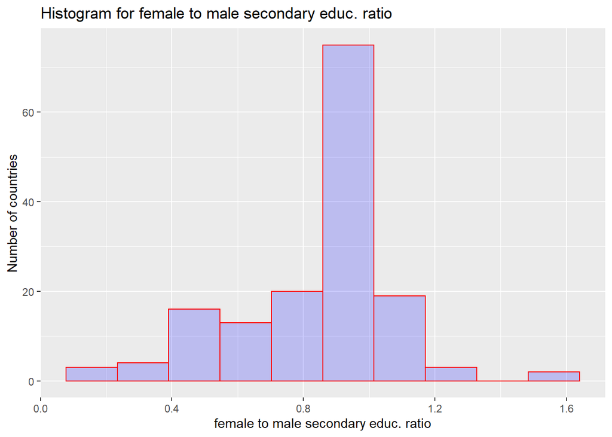

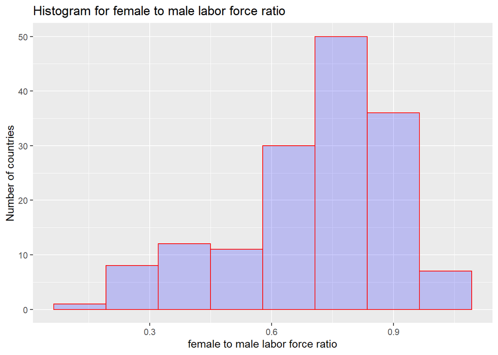

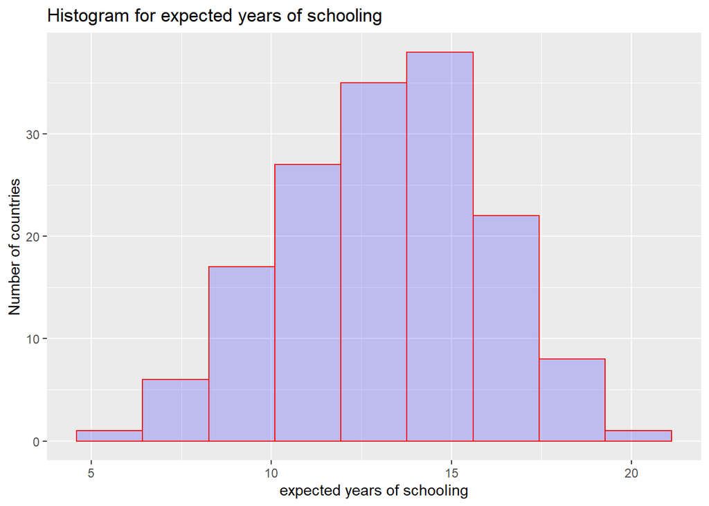

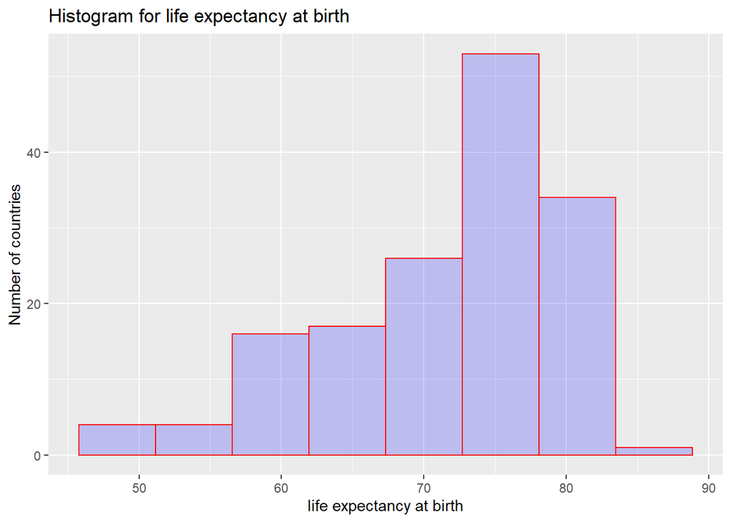

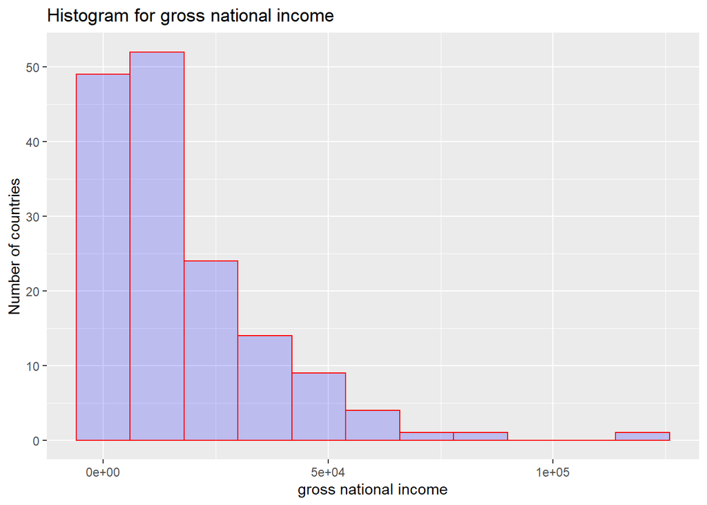

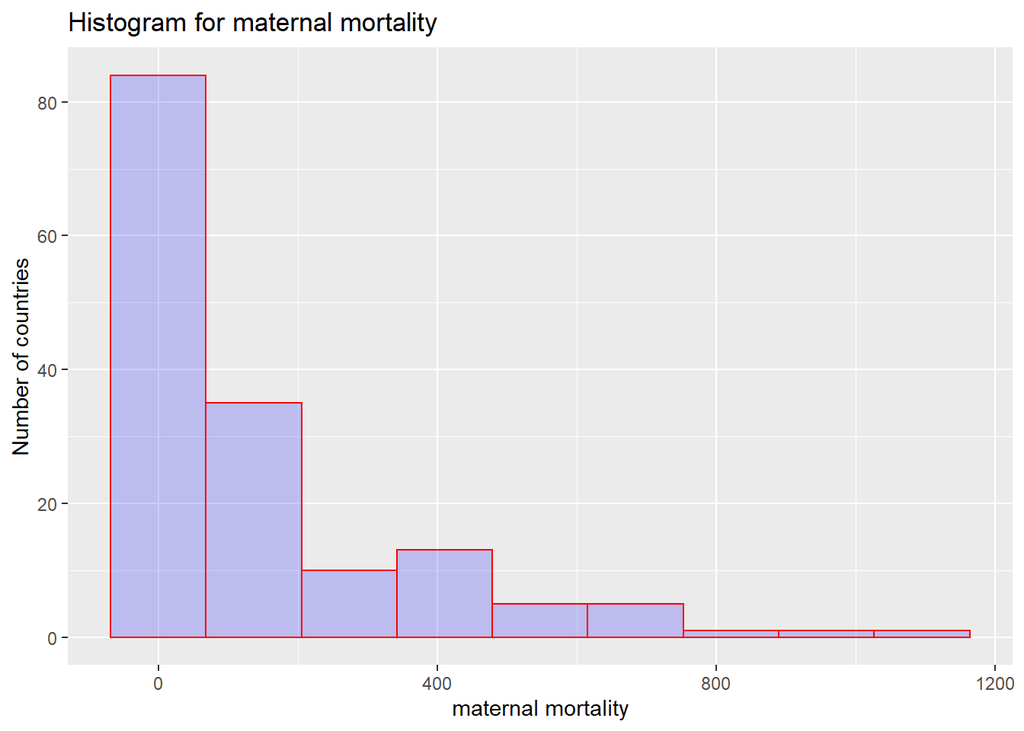

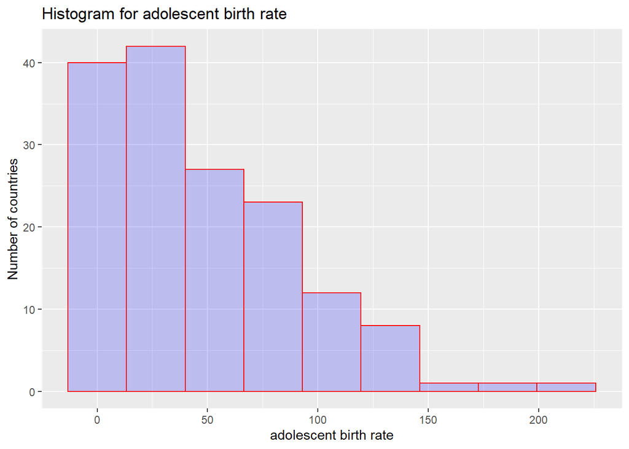

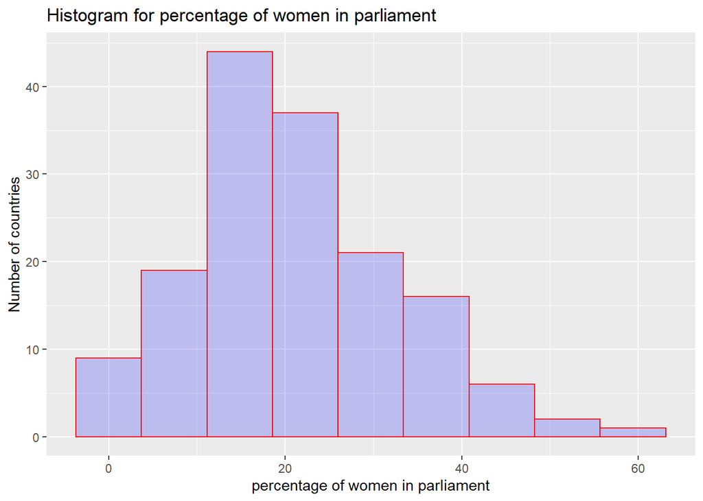

```r
for(var in selvars) {

 # if(is.numeric(var)){
  #  a = a +1
 #   plot <-ggplot(human, aes(var, ..count..)) + geom_bar() + xlab(varlabels[a]) + ylab("")
#  print(plot)

#} else {
    a = a +1
    plot <- qplot(var,
      geom="histogram",
      binwidth = ((1/5.4) * sd(var)) * 3.49,
      main = paste("Histogram for", varlabels[a])  ,
      xlab = (varlabels[a]),
      ylab = ("Number of countries"),
      fill=I("blue"),
      col=I("red"),
      alpha=I(.2))
    print(plot)
 #   }
}
```

Let’s check the corellations between these variables.

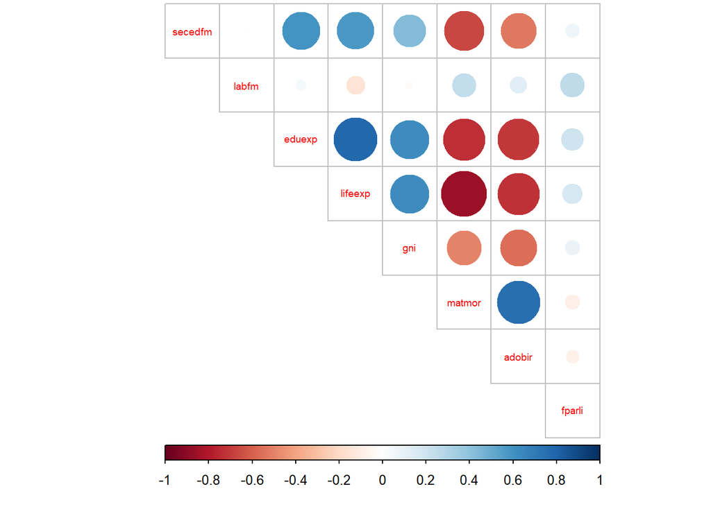

```r
cor_matrix<-cor(human)

corrplot(cor_matrix, method="circle", type="upper", cl.pos = "b", tl.pos = "d", tl.cex = 0.6)
```

Strong negative associations were between 1. maternal mortality and life expectancy at birth 2. exposure to education and maternal mortality 3. Adolescent borth rate and life expectancy. Strong positive corellations were between 1. Adolescent borth rate and maternal mortality 2. Exposure to education and life expectancy.

### Principal componenet analysis

```r
pca_human <- prcomp(human)
s <- summary(pca_human)
pca_pr <- round(100*s$importance[2, ], digits = 1)
pca_pr
```

```
## PC1 PC2 PC3 PC4 PC5 PC6 PC7 PC8
## 100   0   0   0   0   0   0   0
```

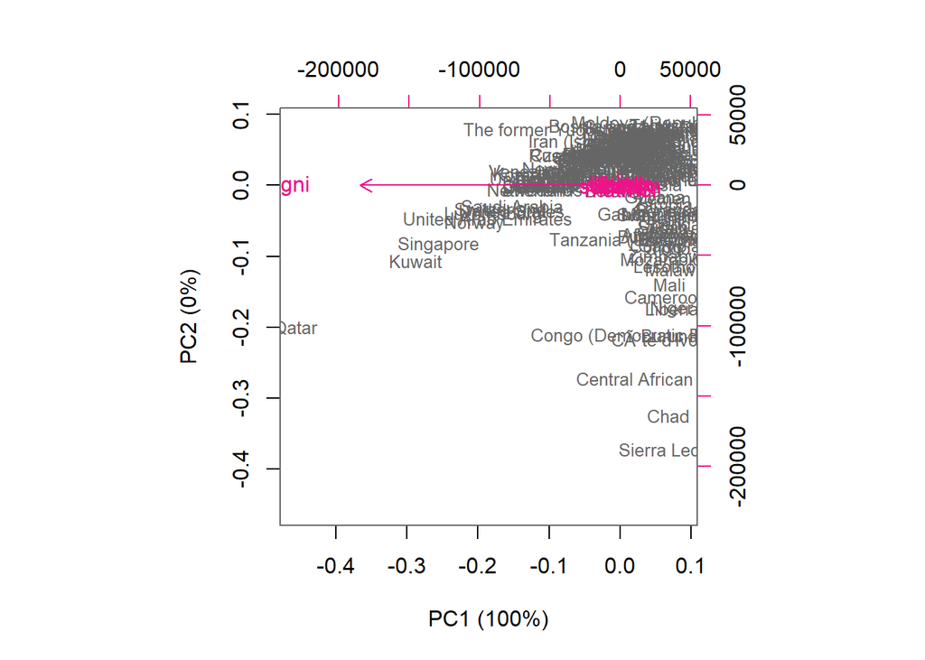

```r
pc_lab <- paste0(names(pca_pr), " (", pca_pr, "%)")
biplot(pca_human, cex = c(0.8, 1), col = c("grey40", "deeppink2"), xlab = pc_lab[1], ylab = pc_lab[2])
```

### Principal componenet analysis (after standardization)

```r
human_std <- scale(human)
pca_human <- prcomp(human_std)
s <- summary(pca_human)
pca_pr <- round(100*s$importance[2, ], digits = 1)
pca_pr
```

```
##  PC1  PC2  PC3  PC4  PC5  PC6  PC7  PC8
## 53.6 16.2  9.6  7.6  5.5  3.6  2.6  1.3
```

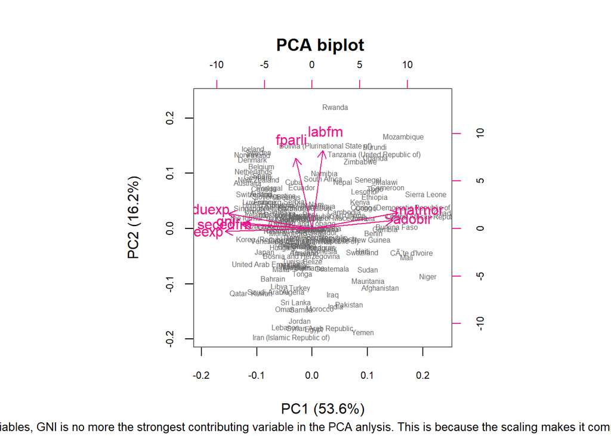

```r
pc_lab <- paste0(names(pca_pr), " (", pca_pr, "%)")
biplot(pca_human, cex = c(0.5, 1), cex.axis = 0.7, col = c("grey40", "deeppink2"), xlab = pc_lab[1], ylab = pc_lab[2], main = "PCA biplot ", cex.sub = 0.8, sub = "after standardizing the variables, GNI is no more the strongest contributing variable in the PCA anlysis. This is because the scaling makes it comparable in size to other variables.")
```

```r
?biplot
```

```
## starting httpd help server ... done
```

The results are very different after standardization because standardization changes the scale of the data. Before, one variable (i.e. GNI) had a lot of variability and it was being given the highest weight because of that. PC1 was based entirely on variability within gni. After standardization, other variables could also influence the results.

### Interpretation

According to my interpretation, PCA is the strongest principal component (i.e. catches the highest amount of variability, 53%). It is influenced by maternal mortality, adolescent birth rate in one direction and education exposure, life expectancy, secondary education ratio between men and women, and gni in the other direction.

The second pricipal component captures 16 percent variability in the data. It is influenced by number of women in the parliament and the participation of women in labor force.

### Tea dataset

```r
data("tea")
str(tea)
```

```
## 'data.frame':    300 obs. of  36 variables:
##  $ breakfast       : Factor w/ 2 levels "breakfast","Not.breakfast": 1 1 2 2 1 2 1 2 1 1 ...
##  $ tea.time        : Factor w/ 2 levels "Not.tea time",..: 1 1 2 1 1 1 2 2 2 1 ...
##  $ evening         : Factor w/ 2 levels "evening","Not.evening": 2 2 1 2 1 2 2 1 2 1 ...
##  $ lunch           : Factor w/ 2 levels "lunch","Not.lunch": 2 2 2 2 2 2 2 2 2 2 ...
##  $ dinner          : Factor w/ 2 levels "dinner","Not.dinner": 2 2 1 1 2 1 2 2 2 2 ...
##  $ always          : Factor w/ 2 levels "always","Not.always": 2 2 2 2 1 2 2 2 2 2 ...
##  $ home            : Factor w/ 2 levels "home","Not.home": 1 1 1 1 1 1 1 1 1 1 ...
##  $ work            : Factor w/ 2 levels "Not.work","work": 1 1 2 1 1 1 1 1 1 1 ...
##  $ tearoom         : Factor w/ 2 levels "Not.tearoom",..: 1 1 1 1 1 1 1 1 1 2 ...
##  $ friends         : Factor w/ 2 levels "friends","Not.friends": 2 2 1 2 2 2 1 2 2 2 ...
##  $ resto           : Factor w/ 2 levels "Not.resto","resto": 1 1 2 1 1 1 1 1 1 1 ...
##  $ pub             : Factor w/ 2 levels "Not.pub","pub": 1 1 1 1 1 1 1 1 1 1 ...
##  $ Tea             : Factor w/ 3 levels "black","Earl Grey",..: 1 1 2 2 2 2 2 1 2 1 ...
##  $ How             : Factor w/ 4 levels "alone","lemon",..: 1 3 1 1 1 1 1 3 3 1 ...
```

[output cut: 22 more lines]

```r
dim(tea)
```

```
## [1] 300  36
```

The tea dataset is a part of factominer package and contains information about tea drinking preferences of 300 individuals.

Following is a distribution of participants according to their age and gender.

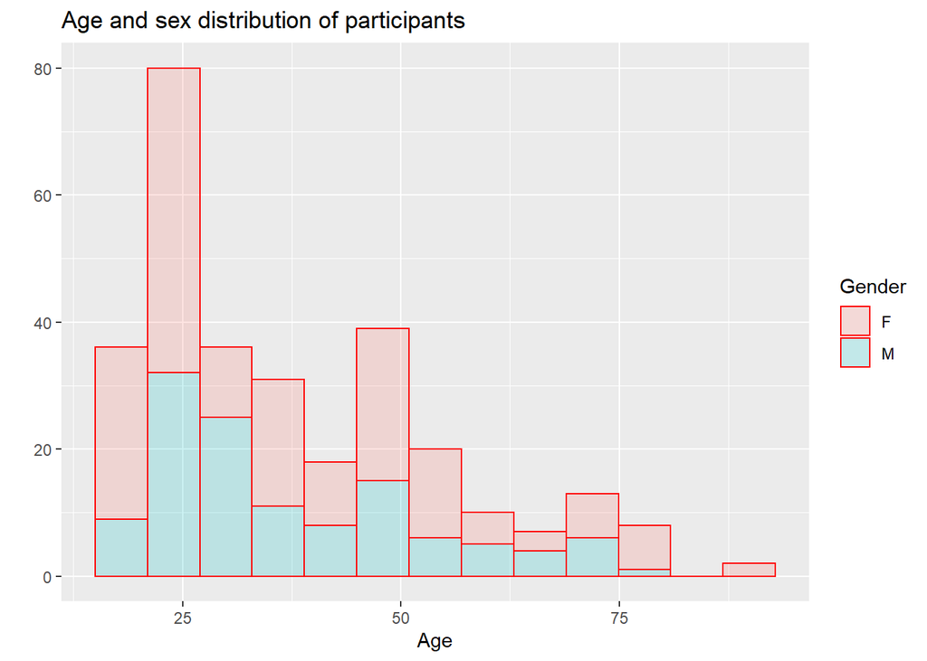

```r
  age <- tea$age
      plot <- qplot(age,
      geom="histogram",
      binwidth = ((1/6.69) * sd(var)) * 3.49,
      main = paste("Age and sex distribution of participants")  ,
      xlab = ("Age"),
      fill=tea$sex,
      col=I("red"),
      alpha=I(.2)) + scale_fill_discrete(name = "Gender")
    print(plot)
```

The following graphs describe the characteristics of the individuals in terms of key varaibale groups. First we explore the time preference for cosuming tea, i.e. lunch, evenign or dinner. IN the second group we explore the location where they consume tea usually and from where they purchase it. In the third group we explore how the tea is consumed.

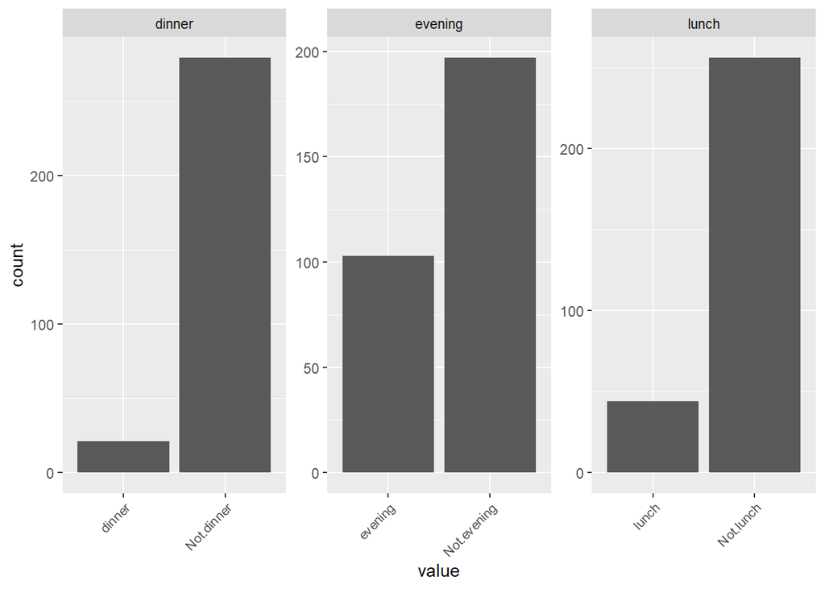

```r
selcols <- c("evening", "dinner", "lunch")
group1 <-select(tea, one_of(selcols))
gather(group1) %>% ggplot(aes(value)) + geom_bar() + facet_wrap("key", scales = "free") + theme(axis.text.x = element_text(angle = 45, hjust = 1, size = 8))
```

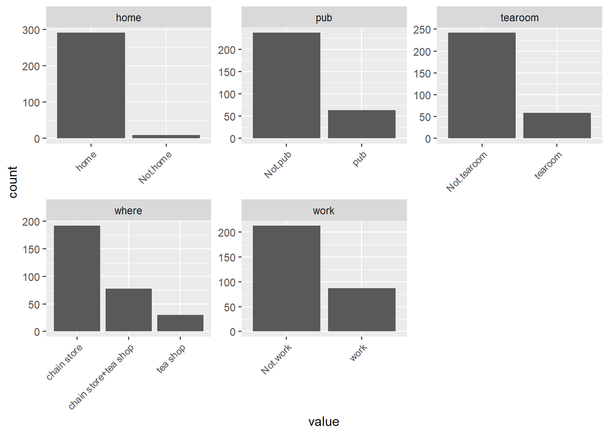

```r
selcols <- c("home", "pub", "work", "tearoom", "where")
group2 <-select(tea, one_of(selcols))
gather(group2) %>% ggplot(aes(value)) + geom_bar() + facet_wrap("key", scales = "free") + theme(axis.text.x = element_text(angle = 45, hjust = 1, size = 8))
```

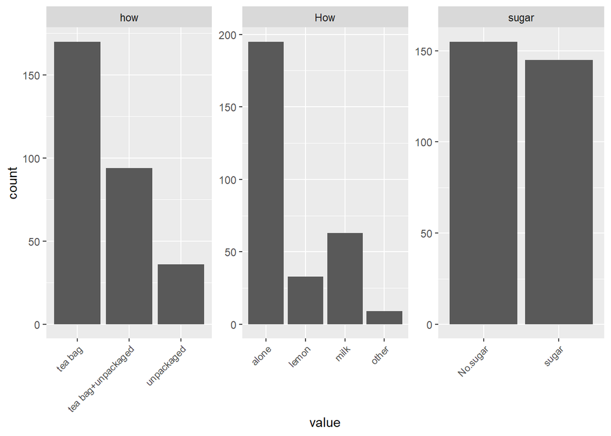

```r
selcols <- c("How", "sugar", "how")
group2 <-select(tea, one_of(selcols))
gather(group2) %>% ggplot(aes(value)) + geom_bar() + facet_wrap("key", scales = "free") + theme(axis.text.x = element_text(angle = 45, hjust = 1, size = 8))
```

### Multiple correspondence analysis

I chose certain groups for the purpose of analyses.

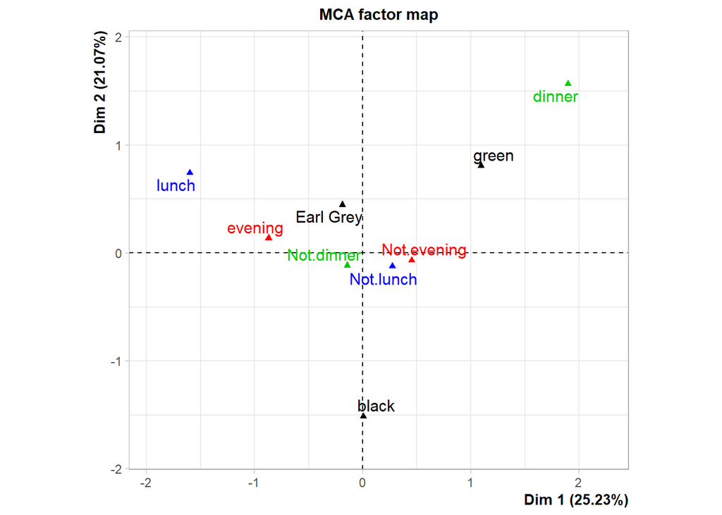

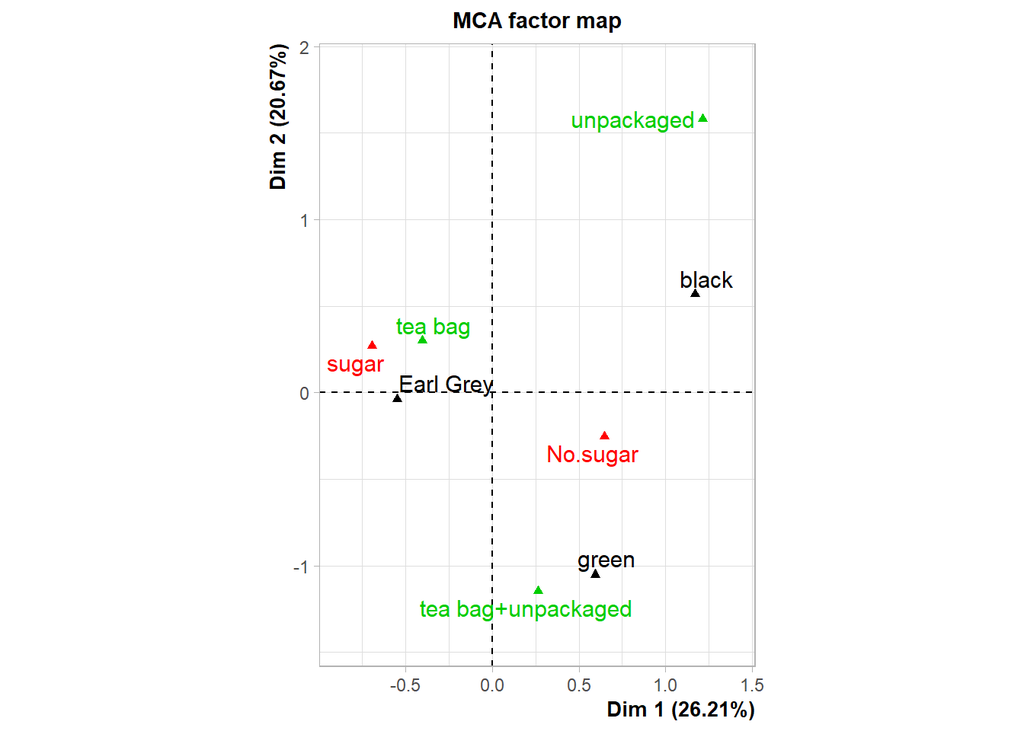

```r
#c("Tea" ,"evening", "dinner", "lunch", "sugar", "where", "home", "pub", "work", "tearoom" , "how","How", "sugar")

grp1 <- c("Tea" ,"evening", "dinner", "lunch")
grp2 <- c("Tea", "sugar", "how")
grp <- c()

a=0

for (num in 1:2) {
a=a+1

curgrp <- get(paste('grp',a, sep = ''))
curgrp
tea_mca <- select(tea, one_of(curgrp))

#gather(tea_mca) %>% ggplot(aes(value)) + geom_bar() + facet_wrap("key", scales = "free") + theme(axis.text.x = element_text(angle = 45, hjust = 1, size = 8))

mca <- MCA(tea_mca, graph = FALSE)

p <- plot(mca, invisible=c("ind"), habillage = "quali")
print(p)

}
```

1. I first wanted to investigate is the time of consuming tea is related to the type of tea consumed. I found that green tea is usually consumed for dinner. Earl grey and black are usually not consumed for dinner. People were most likely to not consume tea with lunch.
2. In the second group of variables, I found that Earl Greay is usually consumed in tea bag for and with sugar. Green tea is bought both packaged and unpackaged and black tea is mostly bought unpackaged Sygar is susually not added to green or black tea.